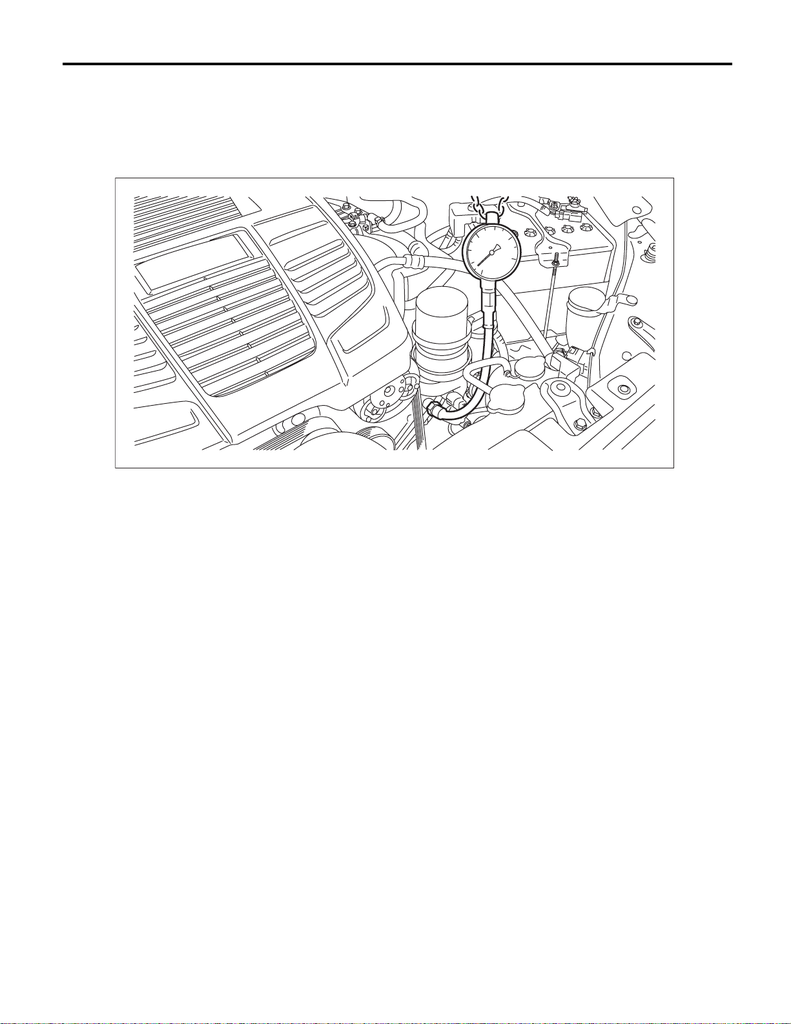

Engine Oil Pressure

MECHANICAL

6. Engine Oil Pressure

A: INSPECTION

1) Disconnect the ground terminal from battery sensor. <Ref. to NT-5, BATTERY, NOTE, Note.>

2) Remove the oil pressure switch. <Ref. to LU(w/o STI)-31, REMOVAL, Oil Pressure Switch.>

3) Install the oil pressure gauge to the chain cover.

4) Connect the ground terminal to battery sensor. <Ref. to NT-5, BATTERY, NOTE, Note.>

5) Start the engine, and check the oil pressure.

NOTE:

• Standard value is based on an engine oil temperature of 80°C (176°F).

72, INSPECTION, Engine Lubrication System Trouble in General.>

• If the oil pressure warning light is ON and oil pressure is within standard, check the oil pressure switch.

<Ref. to LU(w/o STI)-72, INSPECTION, Engine Lubrication System Trouble in General.>

Engine oil pressure:

Standard

2

, 7 psi) or more (at 600 rpm)

2

, 51 psi) or more (at 6,000 rpm)

6) After inspection, install the related parts in the reverse order of removal.

ME-07900